# WUP_04

Alondra Garcia

Summer 2022

# Introduction

The data is in the file GSScsv.csv and came from the 2018 General Social Survey. The question to answer is to resolve this hypothesis.  
$H_0$ There is no difference between the average score on the WORDSUM test and level of schooling DEGREE  
$H_a$ There is a significant difference in average score on the WORDSUM test between at least two levels of DEGREE

# Methods

```r
gssDataframe=read.csv("GSScsv.csv")
```

WORDSUM is a numerical variable and DEGREE is a categorical variable

# Results

## Descriptive Results

### Graphical Descriptive Results

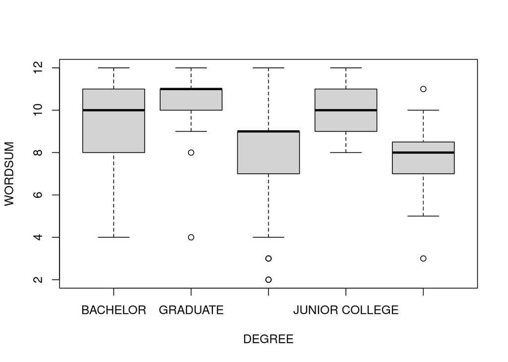

```r
boxplot(WORDSUM~DEGREE,data=gssDataframe)
```

From the boxplot it appears that the students in high school have a median less than that of students in high school and in Bachelor

### Numerical Descriptive Results

```r
favstats(WORDSUM~DEGREE,data=gssDataframe)
```

| DEGREE | min | Q1 | median | Q3 | max | mean | sd | n | missing |
| --- | --- | --- | --- | --- | --- | --- | --- | --- | --- |
| BACHELOR | 4 | 8 | 10 | 11.00 | 12 | 9.204545 | 2.052560 | 44 | 0 |
| GRADUATE | 4 | 10 | 11 | 11.00 | 12 | 10.095238 | 1.729299 | 21 | 0 |
| HIGH SCHOOL | 2 | 7 | 9 | 9.00 | 12 | 8.282353 | 2.234000 | 85 | 0 |
| JUNIOR COLLEGE | 8 | 9 | 10 | 11.00 | 12 | 9.916667 | 1.378954 | 12 | 0 |
| LT HIGH SCHOOL | 3 | 7 | 8 | 8.25 | 11 | 7.750000 | 1.949359 | 16 | 0 |

From this table, it appears that the median of the Graduate students is the greatest with a 11. It looks like there is a difference in the ability in the WORDSUM category.

## Inferential Results

```r
model1 <- aov(WORDSUM~DEGREE,data=gssDataframe)
summary.aov(model1)
```

```
##              Df Sum Sq Mean Sq F value   Pr(>F)
## DEGREE        4   97.8  24.445   5.729 0.000236 ***
## Residuals   173  738.1   4.267
## ---
## Signif. codes:  0 '***' 0.001 '**' 0.01 '*' 0.05 '.' 0.1 ' ' 1
```

P-value is 0.000236, because the p-value is less than 0.05, we reject the null hypothesis.

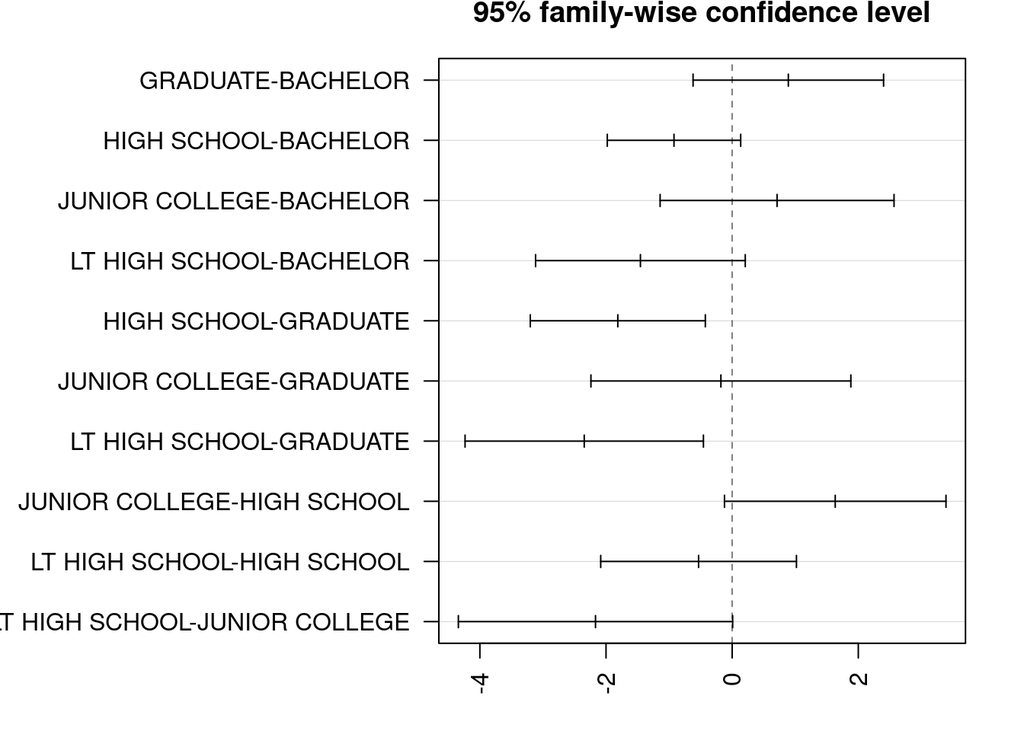

```r
#we specify the margins starting at the bottom and proceeding clockwise - thus 8.7 is the left side margin to hold the names of the factors
par(mar = c(3, 15, 2, 2))
plot(TukeyHSD(model1),las=2)
```

Based on the graph there is a difference between High School Graduae and also between Less than High School and Graduate. This is because those levels do not cross or touch the zero

# Discussion and Conclusion

There is a significant difference between the variables, for this reason we reject the null hypothesis.